# **Introdução**

Neste laboratório, foram utilizadas as bibliotecas OpenCV2 e MatplotLib, dentro do ambiente de desenvolvimento do Google Colab, para codificação de imagens através da técnica de DCT(Transformada Discreta de Cosseno), além do estudo de funções para compressão de imagens com perdas, utilizando a linguagem Python.

Foi desenvolvida ainda uma animação 3D, dentro do Software Blender, fazendo uso dos efeitos de iluminação e fundamentos de animação (keyframes).

Abaixo, temos a importação das bibliotecas utilizadas ao longo do código utilizado nesta prática:

```python
import numpy as np
import cv2 as cv
import matplotlib.pyplot as plt
from IPython.display import HTML
from base64 import b64encode
import os
import pandas as pd
```

# **Estudo da separação das camadas de cores**

O primeiro passo para separar as camadas de cores das imagens, foi a Leitura da imagem e suas dimensões com biblioteca OpenCV2.

1. A função `.imread` lê a imagem no formato BGR

O código utilizado e o resultado obtido, podem ser vistos abaixo:

```python
bgr1 = cv.imread('/content/messi.jpg') # leitura no formato BGR!
altura, largura, camadas = bgr1.shape
print("Resolução: ", largura, " x ", altura, "PIXELS. ", camadas, " camadas.")
```

```
Resolução:  548  x  342 PIXELS.  3  camadas.
```

O segundo passo se trata de Separar os canais e re-arranjar, para formar uma imagem RGB:

1. A função `.split` permite que separemos as cores azul, verde e vermelho da imagem
2. A função `.merge` re-arranja as cores para formar a imagem em RGB

```python
b1, g1, r1 = cv.split(bgr1)
rgb2 = cv.merge([r1,g1,b1])
```

Terceiro passo: Imprime cores trocadas (BGR) e reais (RGB)

[figure not shown]

```python
plt.figure(figsize=[12, 5])
plt.subplot(121); plt.imshow(bgr1); plt.title('BGR')
plt.subplot(122); plt.imshow(rgb2); plt.title('RBG')
```

Quarto Passo: Converte para os formatos YCrCb e HSV

[figure not shown]

```python
ycrcb = cv.cvtColor(bgr1, cv.COLOR_BGR2YCrCb)
hsv = cv.cvtColor(bgr1, cv.COLOR_BGR2HSV)
plt.figure(figsize=[15,6])
plt.subplot(131); plt.imshow(rgb2); plt.title('RGB')
plt.subplot(132); plt.imshow(ycrcb); plt.title('YCrCb')
plt.subplot(133); plt.imshow(hsv); plt.title('HSV')
```

Quinto Passo: Separação das Camadas RGB individualmente

Manipulando as matrizes é possivel apagar a presença da cores não desejadas zerando suas respectivas colunas

[figure not shown]

```python
imageR = rgb2.copy()
imageR[:, :, 1:3] = 0
imageG = rgb2.copy()
imageG[:, :, 0] = 0; imageG[:, :, 2] = 0
imageB = rgb2.copy()
imageB[:, :, 0:2] = 0

plt.figure(figsize=[15,6])
plt.subplot(131); plt.imshow(imageR); plt.title('RGB_Camada R')
plt.subplot(132); plt.imshow(imageG); plt.title('RGB_Camada G')
plt.subplot(133); plt.imshow(imageB); plt.title('RGB_Camada B')
```

Separação dos Canais YCbCr

[figure not shown]

```python
y1, cr1, cb1 = cv.split(ycrcb)
imageCR = ycrcb.copy()
imageCR[:, :, 0] = 0
imageCR[:, :, 2] = 0
Cr = cv.cvtColor(imageCR, cv.COLOR_YCrCb2RGB)

imageCB = ycrcb.copy()
imageCB[:, :, 0] = 0
imageCB[:, :, 1] = 0
Cb = cv.cvtColor(imageCB, cv.COLOR_YCrCb2RGB)

plt.figure(figsize=[15, 5])
plt.subplot(141); plt.imshow(rgb2); plt.title('RGB original')
plt.subplot(142); plt.imshow(y1, cmap='gray'); plt.title('YCrCb_Y')
plt.subplot(143); plt.imshow(Cr); plt.title('YCrCb_Cr')
plt.subplot(144); plt.imshow(Cb); plt.title('YCrCb_Cb')
```

# **Parte 1 - Codificação de Imagem por DCT**

## **1.1.COMPRESSÃO DE IMAGENS COM PERDAS**

1. A função `cv.IMWRITE_JPEG_QUALITY` permite salvar e alterar a qualidade da imagem
- O formato JPEG permite compressão da imagem ao salvá-la num arquivo com o comando imwrite().
- A compressão afeta a qualidade da imagem, sendo controlada pelo parâmetro IMWRITE_JPEG_QUALITY entre 0-100, sendo que quanto maior, melhor a qualidade. O default é 95.
1. Plotamos as imagens que criamos comprimida e convertida de bgr para rgb

```python
def Comprimir_perda(path):
  bgr = cv.imread(path)  # formato BGR

  # salva com menor qualidade, fatores 25 e 5
  cv.imwrite('lena25.jpg', bgr, [cv.IMWRITE_JPEG_QUALITY, 25])
  cv.imwrite('lena05.jpg', bgr, [cv.IMWRITE_JPEG_QUALITY, 5])

  # leitura para visualização e conversão para acertar a cor
  rgb = cv.cvtColor(bgr, cv.COLOR_BGR2RGB)
  bgr25 = cv.imread('lena25.jpg'); rgb25 = cv.cvtColor(bgr25, cv.COLOR_BGR2RGB)
  bgr05 = cv.imread('lena05.jpg'); rgb05 = cv.cvtColor(bgr05, cv.COLOR_BGR2RGB)

  plt.figure(figsize=[15,6])
  plt.subplot(131); plt.imshow(rgb); plt.title('RGB Original')
  plt.subplot(132); plt.imshow(rgb25); plt.title('JPEG fator 25')
  plt.subplot(133); plt.imshow(rgb05); plt.title('JPEG fator 05')
```

### Integrante 1

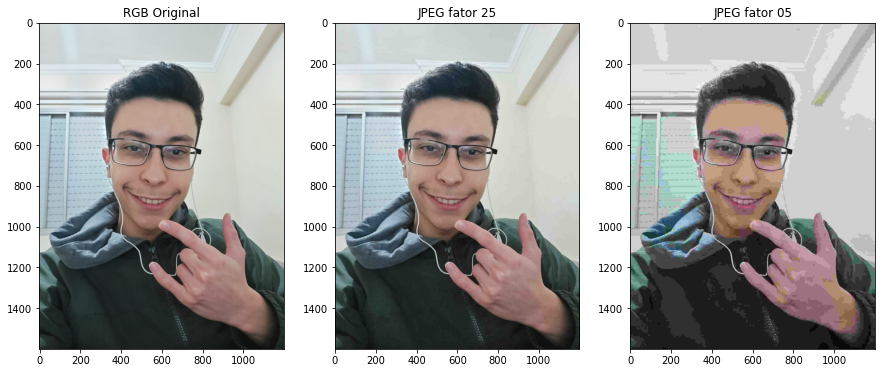

```python
Comprimir_perda('/content/Bieljpg.jpg')
```

### Integrante 2

[figure not shown]

```python
Comprimir_perda('/content/jow.png')
```

### Integrante 3

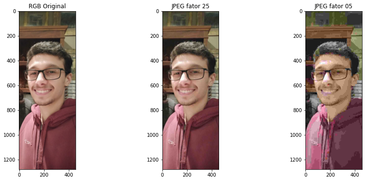

```python
Comprimir_perda('/content/Vitao.png')
```

### Grupo

[figure not shown]

```python
Comprimir_perda('/content/foto_grupo.jpg')
```

## **1.2.TRANSFORMADA DISCRETA COSSENO**

Através da análise dos coeficientes da DCT, é possível perceber o prevalecimento de alguns valores em detrimentos de outros, estes que por sua vez são “menos relevantes” para a composição da imagem. Desse modo, estes coeficientes menores acabam normalmente sendo desprezados (o que corresponde a substituí-los por zero), sem que a imagem sofra grandes deformações.

Nesta parte calculamos a DCT em bloco de 8x8 das imagens do grupo, através da função `DCT_8()`

```python
def DCT_8(path,wid = [280,340],hei = [330,390]):
  img = cv.imread(path)
  alt, larg, cam = img.shape

  ycbcr = cv.cvtColor(img, cv.COLOR_BGR2YCrCb)
  y, cr, cb = cv.split(ycbcr)

  bola = y[wid[0]:wid[1], hei[0]:hei[1]]#60x60
  h, w = bola.shape

  cx = round(w/2)
  cy = round(h/2)

  # Escolhendo um pedaço da imagem
  bloco8x8 = bola[cx-4:cx+4, cy-4:cy+4]#8x8
  #print("(1)"); print("Matriz 8x8: componente Y original")
  #print(bloco8x8)

  bloco8x8f = np.float32(bloco8x8)/255.0  # conversão para float
  dct8x8f = cv.dct(bloco8x8f)   # calcula a DCT
  dct8x8 = np.int64( (dct8x8f*255.0)) # coversão para inteiro

  return bloco8x8, dct8x8,dct8x8f
```

Posteriormente, zeramos todas as posições da matriz abaixo da diagonal secundária, através da Função abaixo para zerar as componentes AC da diagonal da DCT.

```python
def zera_matriz(DCT_Float):
  dct8x8fz = DCT_Float.copy()
  dct8x8fz[0,7] = 0
  dct8x8fz[1,6:8] = 0
  dct8x8fz[2,5:8] = 0
  dct8x8fz[3,4:8] = 0
  dct8x8fz[4,3:8] = 0
  dct8x8fz[5,2:8] = 0
  dct8x8fz[6,1:8] = 0
  dct8x8fz[7,0:8] = 0
  display( pd.DataFrame(np.around(dct8x8fz, decimals = 2)))
  return dct8x8fz
```

Finalmente, temos a Função que plota o Bloco Original e Reconstruído com Zeros, tendo as componentes AC da diagonal secundária para baixo zeradas.

```python
def plota_DCT(DCT_Zerado,og,original_name,output):
  bloco8x8recz = cv.idct(DCT_Zerado)

  plt.subplot(121); plt.imshow(og,'gray'); plt.title('Bloco Original')
  plt.subplot(122); plt.imshow(bloco8x8recz,'gray'); plt.title('Bloco Reconstruído com Zeros')

  cv.imwrite(original_name,og)
  cv.imwrite(output,bloco8x8recz)
  return bloco8x8recz
```

### **Integrante 1**

|  | 0 | 1 | 2 | 3 | 4 | 5 | 6 | 7 |
| --- | --- | --- | --- | --- | --- | --- | --- | --- |
| 0 | 5.96 | 0.29 | -0.13 | -0.23 | 0.04 | 0.08 | 0.02 | 0.0 |
| 1 | 0.31 | 0.15 | 0.00 | -0.05 | -0.07 | -0.01 | 0.00 | 0.0 |
| 2 | -0.13 | 0.04 | -0.10 | 0.09 | 0.04 | 0.00 | 0.00 | 0.0 |
| 3 | -0.02 | 0.03 | 0.07 | 0.10 | 0.00 | 0.00 | 0.00 | 0.0 |
| 4 | -0.01 | -0.00 | 0.15 | 0.00 | 0.00 | 0.00 | 0.00 | 0.0 |
| 5 | 0.05 | -0.03 | 0.00 | 0.00 | 0.00 | 0.00 | 0.00 | 0.0 |
| 6 | -0.01 | 0.00 | 0.00 | 0.00 | 0.00 | 0.00 | 0.00 | 0.0 |
| 7 | 0.00 | 0.00 | 0.00 | 0.00 | 0.00 | 0.00 | 0.00 | 0.0 |

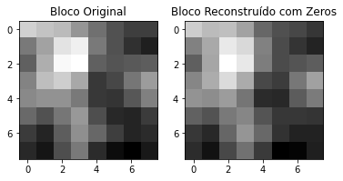

```python
Integrante_1_og, Integrante_1_int, Integrante_1_float  = DCT_8("/content/Bieljpg.jpg")[0], DCT_8("/content/Bieljpg.jpg")[1], DCT_8("/content/Bieljpg.jpg")[2]

Integrante_1_zero = zera_matriz(Integrante_1_float)

plota_DCT(Integrante_1_zero, Integrante_1_og,"Integrante1_original.jpg","Integrante1_dct.jpg");
```

### **Integrante 2**

|  | 0 | 1 | 2 | 3 | 4 | 5 | 6 | 7 |
| --- | --- | --- | --- | --- | --- | --- | --- | --- |
| 0 | 2.07 | -0.11 | -0.02 | -0.02 | 0.01 | 0.01 | 0.0 | 0.0 |
| 1 | 0.22 | -0.02 | -0.01 | -0.04 | -0.01 | 0.01 | 0.0 | 0.0 |
| 2 | 0.01 | 0.04 | -0.02 | 0.00 | -0.01 | 0.00 | 0.0 | 0.0 |
| 3 | 0.01 | 0.03 | 0.01 | 0.01 | 0.00 | 0.00 | 0.0 | 0.0 |
| 4 | -0.02 | -0.01 | 0.01 | 0.00 | 0.00 | 0.00 | 0.0 | 0.0 |
| 5 | -0.02 | -0.02 | 0.00 | 0.00 | 0.00 | 0.00 | 0.0 | 0.0 |
| 6 | 0.02 | 0.00 | 0.00 | 0.00 | 0.00 | 0.00 | 0.0 | 0.0 |
| 7 | 0.00 | 0.00 | 0.00 | 0.00 | 0.00 | 0.00 | 0.0 | 0.0 |

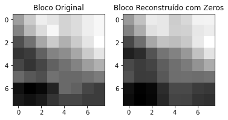

```python
Integrante_2_og, Integrante_2_int, Integrante_2_float  = DCT_8("/content/jow.png")[0], DCT_8("/content/jow.png")[1], DCT_8("/content/jow.png")[2]

Integrante_2_zero = zera_matriz(Integrante_2_float)

plota_DCT(Integrante_2_zero, Integrante_2_og,"Integrante2_original.jpg","Integrante2_dct.jpg");
```

### **Integrante 3**

|  | 0 | 1 | 2 | 3 | 4 | 5 | 6 | 7 |
| --- | --- | --- | --- | --- | --- | --- | --- | --- |
| 0 | 2.83 | -0.31 | 0.05 | 0.03 | -0.05 | -0.00 | -0.03 | 0.0 |
| 1 | 0.23 | 0.18 | -0.00 | -0.09 | -0.02 | -0.07 | 0.00 | 0.0 |
| 2 | -0.03 | -0.04 | -0.09 | -0.06 | -0.04 | 0.00 | 0.00 | 0.0 |
| 3 | 0.07 | -0.26 | -0.01 | 0.05 | 0.00 | 0.00 | 0.00 | 0.0 |
| 4 | -0.11 | 0.10 | 0.03 | 0.00 | 0.00 | 0.00 | 0.00 | 0.0 |
| 5 | 0.02 | -0.02 | 0.00 | 0.00 | 0.00 | 0.00 | 0.00 | 0.0 |
| 6 | -0.02 | 0.00 | 0.00 | 0.00 | 0.00 | 0.00 | 0.00 | 0.0 |
| 7 | 0.00 | 0.00 | 0.00 | 0.00 | 0.00 | 0.00 | 0.00 | 0.0 |

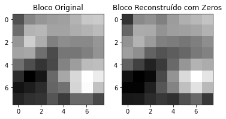

```python
Integrante_3_og, Integrante_3_int, Integrante_3_float  = DCT_8("/content/Vitao.png")[0], DCT_8("/content/Vitao.png")[1], DCT_8("/content/Vitao.png")[2]

Integrante_3_zero = zera_matriz(Integrante_3_float)

plota_DCT(Integrante_3_zero, Integrante_3_og,"Integrante3_original.jpg","Integrante3_dct.jpg");
```

### **Montagem Grupo**

|  | 0 | 1 | 2 | 3 | 4 | 5 | 6 | 7 |
| --- | --- | --- | --- | --- | --- | --- | --- | --- |
| 0 | 0.98 | 0.08 | 0.04 | 0.02 | 0.02 | 0.02 | 0.01 | 0.0 |
| 1 | -0.00 | -0.01 | -0.00 | 0.01 | 0.02 | 0.01 | 0.00 | 0.0 |
| 2 | -0.01 | -0.00 | 0.01 | 0.01 | -0.00 | 0.00 | 0.00 | 0.0 |
| 3 | 0.00 | 0.00 | 0.00 | 0.00 | 0.00 | 0.00 | 0.00 | 0.0 |
| 4 | -0.02 | -0.02 | 0.00 | 0.00 | 0.00 | 0.00 | 0.00 | 0.0 |
| 5 | -0.00 | -0.00 | 0.00 | 0.00 | 0.00 | 0.00 | 0.00 | 0.0 |
| 6 | -0.00 | 0.00 | 0.00 | 0.00 | 0.00 | 0.00 | 0.00 | 0.0 |
| 7 | 0.00 | 0.00 | 0.00 | 0.00 | 0.00 | 0.00 | 0.00 | 0.0 |

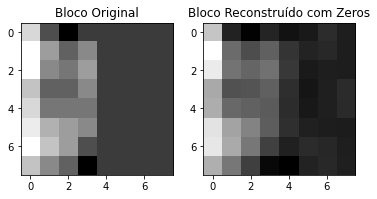

```python
Grupo_og, Grupo_int, Grupo_float  = DCT_8("/content/foto_grupo.jpg")[0], DCT_8("/content/foto_grupo.jpg")[1], DCT_8("/content/foto_grupo.jpg")[2]

Grupo_zero = zera_matriz(Grupo_float)

plota_DCT(Grupo_zero, Grupo_og,"Grupo_original.jpg","Grupo_dct.jpg");
```

### **Comparativo**

Podemos observar que as imagens comprimidadas foram armazenadas com menor quantidade de bytes do que as suas iniciais, demonstrando que o objetivo do laboratório foi cumprido.

Abaixo temos a tabela comparativa, mostrando o percentual de compressão alcançado com a codificação DCT.

```python
original_size = [os.path.getsize("Integrante1_original.jpg"), os.path.getsize("Integrante2_original.jpg"),os.path.getsize("Integrante3_original.jpg"),os.path.getsize("Grupo_original.jpg")]
dct_size =  [os.path.getsize("Integrante1_dct.jpg"),os.path.getsize("Integrante2_dct.jpg"),os.path.getsize("Integrante3_dct.jpg"),os.path.getsize("Grupo_dct.jpg")]

df = pd.DataFrame(data=[original_size,dct_size]).T

df.columns = ["Original(bytes)","DCT(bytes)"]
df["Compressão(%)"] = round(((df["DCT(bytes)"]/df["Original(bytes)"])-1)*100,2)
df["Fotos"] = ["Integrante 1","Integrante 2","Integrante 3","Grupo"]
df
```

|  | Original(bytes) | DCT(bytes) | Compressão(%) | Fotos |
| --- | --- | --- | --- | --- |
| 0 | 365 | 333 | -8.77 | Integrante 1 |
| 1 | 349 | 333 | -4.58 | Integrante 2 |
| 2 | 362 | 333 | -8.01 | Integrante 3 |
| 3 | 343 | 333 | -2.92 | Grupo |

### Escolha outro bloco de 8x8 da imagem e:

1. refaça este procedimento zerando mais DUAS DIAGONAIS ACIMA DA PRINCIPAL além destas
2. Compare e comente as imagens do bloco original e reconstruída

```python
def zera_matriz_2(DCT_Float):
  dct8x8fz = DCT_Float.copy()
  dct8x8fz[0,7] = 0
  dct8x8fz[0,1] = 0
  dct8x8fz[1,2] = 0
  dct8x8fz[2,3] = 0
  dct8x8fz[0,2] = 0
  dct8x8fz[1,3] = 0
  dct8x8fz[2,4] = 0
  dct8x8fz[1,6:8] = 0
  dct8x8fz[2,5:8] = 0
  dct8x8fz[3,4:8] = 0
  dct8x8fz[4,3:8] = 0
  dct8x8fz[5,2:8] = 0
  dct8x8fz[6,1:8] = 0
  dct8x8fz[7,0:8] = 0
  display( pd.DataFrame(np.around(dct8x8fz, decimals = 2)))
  return dct8x8fz
```

#### **Integrante 1**

|  | 0 | 1 | 2 | 3 | 4 | 5 | 6 | 7 |
| --- | --- | --- | --- | --- | --- | --- | --- | --- |
| 0 | 6.70 | 0.0 | 0.0 | 0.0 | 0.0 | 0.0 | 0.0 | 0.0 |
| 1 | -0.03 | 0.0 | 0.0 | 0.0 | 0.0 | 0.0 | 0.0 | 0.0 |
| 2 | 0.00 | 0.0 | 0.0 | 0.0 | 0.0 | 0.0 | 0.0 | 0.0 |
| 3 | -0.00 | 0.0 | 0.0 | 0.0 | 0.0 | 0.0 | 0.0 | 0.0 |
| 4 | 0.00 | 0.0 | 0.0 | 0.0 | 0.0 | 0.0 | 0.0 | 0.0 |
| 5 | -0.01 | 0.0 | 0.0 | 0.0 | 0.0 | 0.0 | 0.0 | 0.0 |
| 6 | 0.00 | 0.0 | 0.0 | 0.0 | 0.0 | 0.0 | 0.0 | 0.0 |
| 7 | 0.00 | 0.0 | 0.0 | 0.0 | 0.0 | 0.0 | 0.0 | 0.0 |

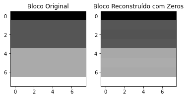

```python
Integrante_1_og, Integrante_1_int, Integrante_1_float  = DCT_8("/content/Bieljpg.jpg",[110,170],[210,270])[0], DCT_8("/content/Bieljpg.jpg",[110,170],[210,270])[1], DCT_8("/content/Bieljpg.jpg",[110,170],[210,270])[2]

Integrante_1_zero = zera_matriz_2(Integrante_1_float)

plota_DCT(Integrante_1_zero, Integrante_1_og,"Integrante1_original_2.jpg","Integrante1_dct_2.jpg");
```

#### **Integrante 2**

|  | 0 | 1 | 2 | 3 | 4 | 5 | 6 | 7 |
| --- | --- | --- | --- | --- | --- | --- | --- | --- |
| 0 | 5.16 | 0.00 | 0.00 | -0.01 | 0.01 | -0.0 | 0.0 | 0.0 |
| 1 | 0.01 | -0.01 | 0.00 | 0.00 | -0.00 | 0.0 | 0.0 | 0.0 |
| 2 | 0.01 | 0.01 | 0.01 | 0.00 | 0.00 | 0.0 | 0.0 | 0.0 |
| 3 | 0.01 | 0.01 | -0.01 | -0.01 | 0.00 | 0.0 | 0.0 | 0.0 |
| 4 | 0.00 | -0.00 | -0.00 | 0.00 | 0.00 | 0.0 | 0.0 | 0.0 |
| 5 | 0.00 | 0.00 | 0.00 | 0.00 | 0.00 | 0.0 | 0.0 | 0.0 |
| 6 | -0.00 | 0.00 | 0.00 | 0.00 | 0.00 | 0.0 | 0.0 | 0.0 |
| 7 | 0.00 | 0.00 | 0.00 | 0.00 | 0.00 | 0.0 | 0.0 | 0.0 |

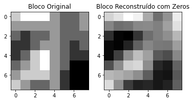

```python
Integrante_2_og, Integrante_2_int, Integrante_2_float  = DCT_8("/content/jow.png",[110,170],[210,270])[0], DCT_8("/content/jow.png",[110,170],[210,270])[1], DCT_8("/content/jow.png",[110,170],[210,270])[2]

Integrante_2_zero = zera_matriz_2(Integrante_2_float)

plota_DCT(Integrante_2_zero, Integrante_2_og,"Integrante2_original_2.jpg","Integrante2_dct_2.jpg");
```

#### **Integrante 3**

|  | 0 | 1 | 2 | 3 | 4 | 5 | 6 | 7 |
| --- | --- | --- | --- | --- | --- | --- | --- | --- |
| 0 | 2.66 | 0.00 | 0.00 | -0.00 | 0.0 | -0.0 | 0.0 | 0.0 |
| 1 | 0.26 | -0.02 | 0.00 | 0.00 | 0.0 | -0.0 | 0.0 | 0.0 |
| 2 | -0.17 | -0.01 | 0.00 | 0.00 | 0.0 | 0.0 | 0.0 | 0.0 |
| 3 | -0.11 | 0.01 | 0.02 | -0.01 | 0.0 | 0.0 | 0.0 | 0.0 |
| 4 | 0.01 | -0.04 | -0.01 | 0.00 | 0.0 | 0.0 | 0.0 | 0.0 |
| 5 | -0.00 | -0.00 | 0.00 | 0.00 | 0.0 | 0.0 | 0.0 | 0.0 |
| 6 | -0.00 | 0.00 | 0.00 | 0.00 | 0.0 | 0.0 | 0.0 | 0.0 |
| 7 | 0.00 | 0.00 | 0.00 | 0.00 | 0.0 | 0.0 | 0.0 | 0.0 |

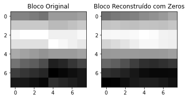

```python
Integrante_3_og, Integrante_3_int, Integrante_3_float  = DCT_8("/content/Vitao.png",[110,170],[210,270])[0], DCT_8("/content/Vitao.png",[110,170],[210,270])[1], DCT_8("/content/Vitao.png",[110,170],[210,270])[2]

Integrante_3_zero = zera_matriz_2(Integrante_3_float)

plota_DCT(Integrante_3_zero, Integrante_3_og,"Integrante3_original_2.jpg","Integrante3_dct_2.jpg");
```

# **Parte 2 - Animação pelo Blender**

Abaixo, temos a visualização da animação feita pelo Blender, sem iluminução de ambiente, tal como exposto durante a aula prática

```python
video1 = "/content/Video sem iluminacao.mkv"
mp4 = open(video1,'rb').read()
video_decodificado = "data:video/mp4;base64," + b64encode(mp4).decode()
HTML(f'<video width="90%" controls><source src= {video_decodificado} type="video/mp4"></video>')
```

[video not shown]

Abaixo, temos a visualização da animação feita com o Software Blender, adicionando a iluminução de ambiente sugerida no roteiro (tipo sky), além de uma luz incidente alaranjada. Podemos ver que o objeto de texto, passa a refletir a cor da luz incidente.

```python
video2 = "/content/Video com Ajuste Iluminação.mkv"
mp4 = open(video2,'rb').read()
video_decodificado = "data:video/mp4;base64," + b64encode(mp4).decode()
HTML(f'<video width="90%" controls><source src= {video_decodificado} type="video/mp4"></video>')
```

[video not shown]

O Software Blender é excelente para animações 3D, mas também pode ser utilizado para animações 2D. O primeiro filme curta-metragem 2D, criado no Blender, foi intitulado “*Hero*” e foi publicado em 2018, como uma demonstração da ferramenta Grease Pencil, introduzida dentro do Software.

A produção de uma animação 2D envolve três fases principais, sendo estas:

1. Pré-produção – Fase de desenvolvimento de Enredo principal, história dos personagens e arte conceitual
2. Produção – Criação e animação dos Personagens cenários finais
3. Pós-Produção – Edição de vídeo, trilha-sonora , mixagem de áudio e correção de cores.

A Ferramenta *Grease Pencil* é o principal instrumento utilizado para produção de uma animação 2D no Blender e consiste num objeto que permite desenhar no espaço tridimensional. Esta ferramenta, conta inclusive com um sistema de layers, ou camadas que possibilita isolar diferentes partes do desenho em folhas distintas.

# **Conclusão**

Neste laboratório, através da manipulação de imagens, foi possível aplicar técnicas de encoding para compressão.

Além das técnicas em si, foi possível aplicar algumas boas práticas para otimizar o processo de encoding. No caso da DCT, isso se dá através da quebra da imagem em blocos 8x8. Não obstante, o laboratório também introduz o estudo à produção de animações, explorando configurações de luz ambiente pelo software Blender.

Em síntese, expandimos algumas premissas previamente definidas em teoria, explorando aplicações práticas de técnicas que podem ser utilizadas no dia-a-dia para compressão de dados e simulações através de animações.

# **AudioDescrição**

```python
HTML(f'<audio controls><source src="https://github.com/gabrielsouza-oss/CSM/blob/main/labs/audio_desc_lab3.mp3?raw=true" type="audio/ogg"></audio>')
```

[interactive chart not shown]